# PSTAT131Final

Shuyu Huang & Yue You

6/15/2018

### 1 What makes predicting voter behavior (and thus election forecasting) a hard problem?

There are various factors that makes predicting voter behavior a hard problem. Some factors are predictable and controllable. First to mention is that the data we used for doing prediction. In this case, we have abundant data from census and about citizens’ voting intentions. When doing research, some factors in census data are useful but may be neglected; while the others are not important but counted, which could result in large variance of models and even overfitting. Also, since when we model the voting behaviors, we use variables such as race and wealth to get a baseline for prediction, outdated data be a big problem. As time goes, many changes would happen such as changes in employment rate and individual income, and so on. Besides, some uncontrollable factors also affect prediction accuracy. When we model the polls, there are some estimation errors including sampling error, dishonest voters’ answers and house effects. Also, people may change their ideas because of scandals, bad news about candidates, which cannot be predicted according to census data. Therefore, it is hard to predict the election results with so many unknowns and unobserved variables. We need to take all these into account and make reasonable adjustments to our model.

### 2. Although Nate Silver predicted that Clinton would win 2016, he gave Trump higher odds than most. What is unique about Nate Silver’s methodology?

On one hand, a small systematic polling error can make a big difference. Polls tend to replicate one another’s mistakes. According to that, Silver’s model is based on how accurate polls have or haven’t been historically, instead of making idealized assumptions about them. He realized that the error is larger in state polls than in national polls. In national polls, the overall effect might be relatively neutral, but in state polls, the error can make a big difference. On the other hand, his model considers possiblities that Clinton underperformed her polls significantly throughout the Midwest and the Rust Belt, and made simulations on these errors. In fact, Clinton’s Electoral College leads weren’t very robust because of her relatively weak polling in the Midwest and swing states. Furthermore, his model not only includes one crucial assumption that polling errors are correlated, but also considers the number of undecided and third-party voters when evaluating the uncertainty in the race.

### 3 Discuss why analysts believe predictions were less accurate in 2016. Can anything be done to make future predictions better? What are some challenges for predicting future elections? How do you think journalists communicate results of election forecasting models to a general audience?

Since major medias, such as The New York Times, did pre-election prediction and most of them predict that Hillary would win with prominent dominance in the election, which contradicts the result of votes. Therefore it is clear to tell that predictions in 2016 was not accurate. During the process of 2016 pollings, public opinion was largely affected by the media and press. Recalling entertaining promotions of Trump, as well as various scandals of Hillary and Trump. Since people can get access to these news easier today and be influenced, analyst may need to count this as an important factor when doing predictions though it is complicated. When journalist communicate results of election forecasting models to general audience. On one hand, may bring misleading ideas through their analysis of the forecasting models and impact people’s intentions. Also, according to herd mentality, people who swing may tend to vote for the candidate wins according to the forecasting model. On the other hand, people can more or less get update of people’s choice and intentions through these report on journal. Therefore it would be a double-edged sword.

## Data wrangling

### 4 Creating data set of Federal-; State-; County-level summary

##### First Several rows of the Original Data (election.raw)

| county | fips | candidate | state | votes |
| --- | --- | --- | --- | --- |
| NA | US | Donald Trump | US | 62984825 |
| NA | US | Hillary Clinton | US | 65853516 |
| NA | US | Gary Johnson | US | 4489221 |
| NA | US | Jill Stein | US | 1429596 |
| NA | US | Evan McMullin | US | 510002 |
| NA | US | Darrell Castle | US | 186545 |

##### First Several rows of the Federal-level date (election_federal)

| county | fips | candidate | state | votes |
| --- | --- | --- | --- | --- |
| NA | US | Donald Trump | US | 62984825 |
| NA | US | Hillary Clinton | US | 65853516 |
| NA | US | Gary Johnson | US | 4489221 |
| NA | US | Jill Stein | US | 1429596 |
| NA | US | Evan McMullin | US | 510002 |
| NA | US | Darrell Castle | US | 186545 |

##### First Several rows of the State-level date (election_state)

| county | fips | candidate | state | votes |
| --- | --- | --- | --- | --- |
| NA | CA | Hillary Clinton | CA | 8753788 |
| NA | CA | Donald Trump | CA | 4483810 |
| NA | CA | Gary Johnson | CA | 478500 |
| NA | CA | Jill Stein | CA | 278657 |
| NA | CA | Gloria La Riva | CA | 66101 |
| NA | FL | Donald Trump | FL | 4617886 |

##### First Several rows of the County-level date (election)

| county | fips | candidate | state | votes |
| --- | --- | --- | --- | --- |
| Los Angeles County | 6037 | Hillary Clinton | CA | 2464364 |
| Los Angeles County | 6037 | Donald Trump | CA | 769743 |
| Los Angeles County | 6037 | Gary Johnson | CA | 88968 |
| Los Angeles County | 6037 | Jill Stein | CA | 76465 |
| Los Angeles County | 6037 | Gloria La Riva | CA | 21993 |
| Cook County | 17031 | Hillary Clinton | IL | 1611946 |

### 5 How many named presidential candidates were there in the 2016 election? Draw a bar chart of all votes received by each candidate

```
## [1] "Number of named presidential candidates is 31"
```

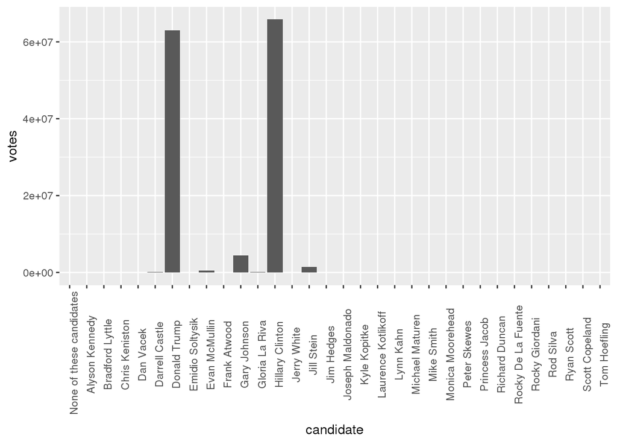

### 6 Create variables county_winner and state_winner by taking the candidate with the highest proportion of votes.

##### First several rows of county_winner

| county | fips | candidate | state | votes | total | pct |
| --- | --- | --- | --- | --- | --- | --- |
| Los Angeles County | 6037 | Hillary Clinton | CA | 2464364 | 3421533 | 0.7202514 |
| Cook County | 17031 | Hillary Clinton | IL | 1611946 | 2156395 | 0.7475189 |
| Maricopa County | 4013 | Donald Trump | AZ | 747361 | 1536743 | 0.4863279 |
| Harris County | 48201 | Hillary Clinton | TX | 707914 | 1305434 | 0.5422825 |
| San Diego County | 6073 | Hillary Clinton | CA | 735476 | 1291078 | 0.5696604 |
| Orange County | 6059 | Hillary Clinton | CA | 609961 | 1186203 | 0.5142130 |

##### First several rows of state_winner

| county | fips | candidate | state | votes | total | pct |
| --- | --- | --- | --- | --- | --- | --- |
| NA | CA | Hillary Clinton | CA | 8753788 | 14060856 | 0.6225644 |
| NA | FL | Donald Trump | FL | 4617886 | 9419886 | 0.4902274 |
| NA | TX | Donald Trump | TX | 4685047 | 8917965 | 0.5253493 |
| NA | NY | Hillary Clinton | NY | 4556124 | 7660190 | 0.5947795 |
| NA | PA | Donald Trump | PA | 2970733 | 6115402 | 0.4857789 |
| NA | IL | Hillary Clinton | IL | 3090729 | 5523142 | 0.5595962 |

## Visualization

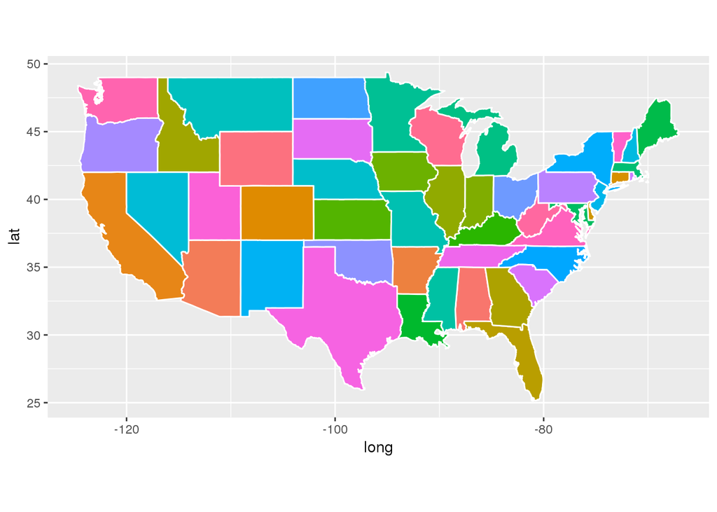

### 7 Draw county-level map. Color by county

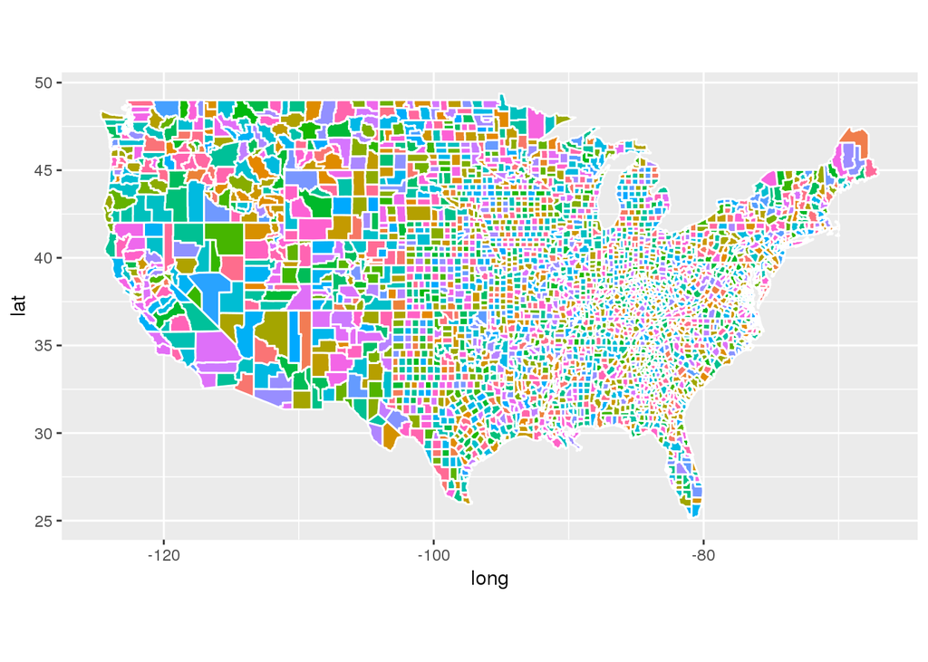

### 8 Color the map by the winning candidate for each state

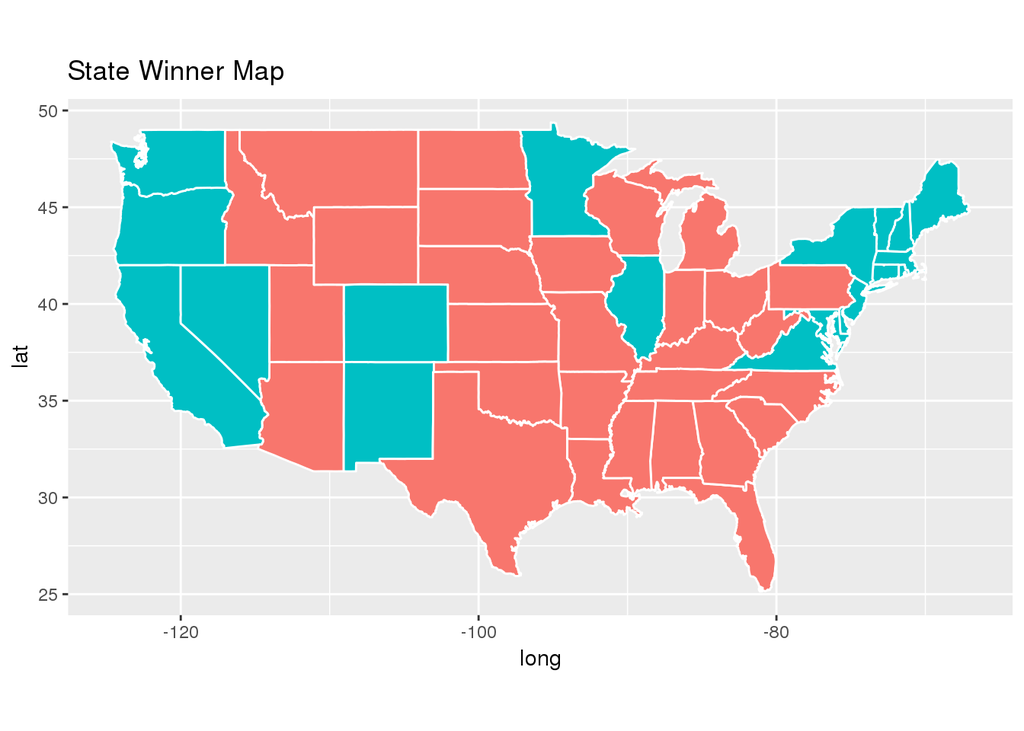

### 9 Color the map by the winning candidate for each county

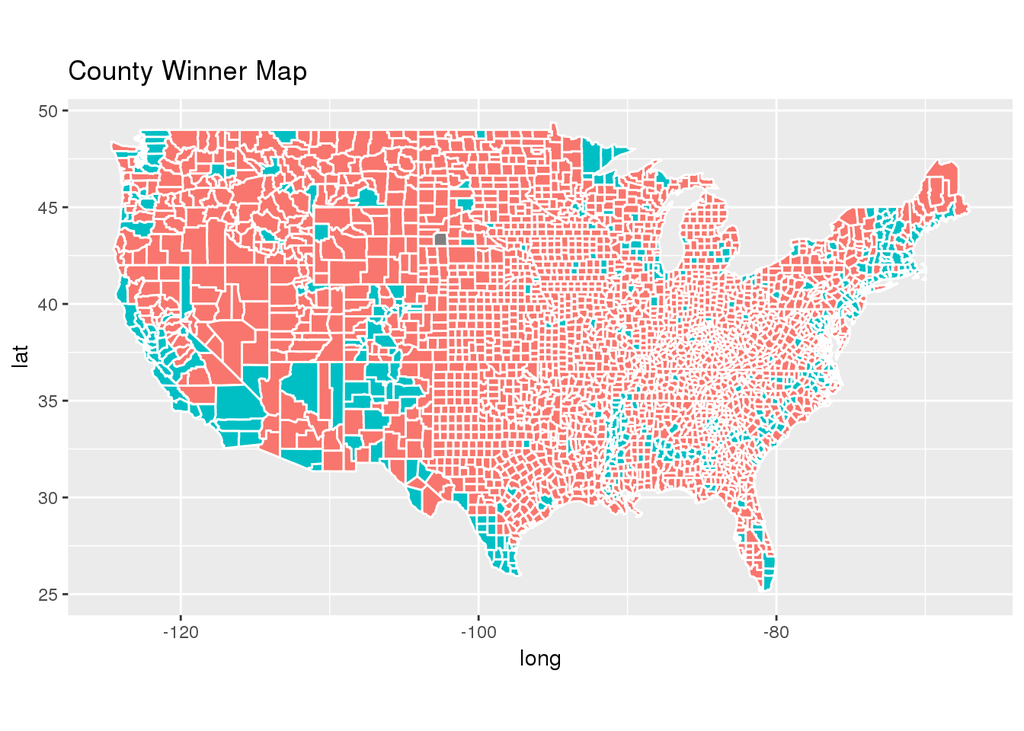

### 10 Create a visualization of your choice using census data.

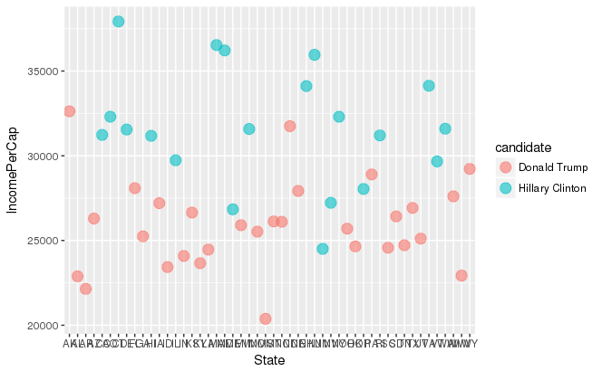

```
  With the demographic: IncomePerCap, we produce a satter plot. The plot has State as x-axis, IncomePerCap as y-axis. Then, we represent the average IncomePerCap on it, with different colors, which represent choices of Hillary or Trump.
  Through this plot, we observe that State with higher average IncomePerCap tends to choose Hillary, and States with lowever IncomePerCap tends to choose Trump.
```

### 11 Aggregate the information into county-level data

| State | County | Men | White | Citizen | Income | IncomeErr | IncomePerCap | IncomePerCapErr | Poverty | ChildPoverty | Professional | Service | Office | Production | Drive | Carpool | Transit | OtherTransp | WorkAtHome | MeanCommute | Employed | PrivateWork | SelfEmployed | FamilyWork | Unemployment | Minority | CountyTotal |
| --- | --- | --- | --- | --- | --- | --- | --- | --- | --- | --- | --- | --- | --- | --- | --- | --- | --- | --- | --- | --- | --- | --- | --- | --- | --- | --- | --- |
| Alabama | Autauga | 48.43266 | 75.78823 | 73.74912 | 51696.29 | 7771.009 | 24974.50 | 3433.674 | 12.91231 | 18.70758 | 32.79097 | 17.17044 | 24.28243 | 17.15713 | 87.50624 | 8.781235 | 0.0952590 | 1.3059687 | 1.8356531 | 26.50016 | 43.43637 | 73.73649 | 5.433254 | 0.0000000 | 7.733726 | 22.53687 | 55221 |
| Alabama | Baldwin | 48.84866 | 83.10262 | 75.69406 | 51074.36 | 8745.050 | 27316.84 | 3803.718 | 13.42423 | 19.48431 | 32.72994 | 17.95092 | 27.10439 | 11.32186 | 84.59861 | 8.959078 | 0.1266209 | 1.4438000 | 3.8504774 | 26.32218 | 44.05113 | 81.28266 | 5.909353 | 0.3633269 | 7.589820 | 15.21426 | 195121 |
| Alabama | Barbour | 53.82816 | 46.23159 | 76.91222 | 32959.30 | 6031.065 | 16824.22 | 2430.189 | 26.50563 | 43.55962 | 26.12404 | 16.46343 | 23.27878 | 23.31741 | 83.33021 | 11.056609 | 0.4954032 | 1.6217251 | 1.5019456 | 24.51828 | 31.92113 | 71.59426 | 7.149837 | 0.0897742 | 17.525557 | 51.94382 | 26932 |
| Alabama | Bibb | 53.41090 | 74.49989 | 77.39781 | 38886.63 | 5662.358 | 18430.99 | 3073.599 | 16.60375 | 27.19708 | 21.59010 | 17.95545 | 17.46731 | 23.74415 | 83.43488 | 13.153641 | 0.5031366 | 1.5620952 | 0.7314679 | 28.71439 | 36.69262 | 76.74385 | 6.637936 | 0.3941515 | 8.163104 | 24.16597 | 22604 |
| Alabama | Blount | 49.40565 | 87.85385 | 73.37550 | 46237.97 | 8695.786 | 20532.27 | 2052.055 | 16.72152 | 26.85738 | 28.52930 | 13.94252 | 23.83692 | 20.10413 | 84.85031 | 11.279222 | 0.3626321 | 0.4199411 | 2.2654133 | 34.84489 | 38.44914 | 81.82671 | 4.228716 | 0.3564928 | 7.699640 | 10.59474 | 57710 |
| Alabama | Bullock | 53.00618 | 22.19918 | 75.45420 | 33292.69 | 9000.345 | 17579.57 | 3110.645 | 24.50260 | 37.29116 | 19.55253 | 14.92420 | 20.17051 | 25.73547 | 74.77277 | 14.839127 | 0.7732160 | 1.8238247 | 3.0998783 | 28.63106 | 36.19592 | 79.09065 | 5.273684 | 0.0000000 | 17.890026 | 76.53587 | 10678 |

## Dimensionality reduction

### 12 Run PCA for both county & sub-county level data

```
Before running PCA we choose CENTER=TRUE and SCALE=TRUE, which is standardizing our data in other words.

For the choice of CENTER:
  Centering is to eliminating the impact of diffenrent level of means of each variable. By using CENTER=TURE, we makes our data has mean=0. It prevents first PC from being denominated by the variables' means.

For the choice of SCALE:
  Scaling makes variables have unit variance before doing PCA analysis. When variables have different levels of variance, PCA, which minimizes variance, would load on the largest variances. Therefore, we use SCALE=TRUE to standardizing variances to prevent from this happening.
```

#### PC1, PC2 for County-level data

| PC1 | PC2 |
| --- | --- |
| -0.3961140 | -0.9818792 |
| -1.1382725 | -1.2409492 |
| 4.2196929 | -0.2845029 |
| 1.9197165 | 1.0351019 |
| 0.6530071 | -0.4596558 |
| 4.0218334 | -1.4245596 |

|  | Largest PC1 loadings |
| --- | --- |
| IncomePerCap | 0.3530767 |
| ChildPoverty | 0.3421530 |

|  | Largest PC2 loadings |
| --- | --- |
| IncomeErr | 0.3145022 |
| SelfEmployed | 0.3087990 |

```
  Therefore, we find features with the largest absolute values in the loadings matrix are IncomePerCap for PC1; IncomeErr for PC2. And in total, IncomePerCap is the largest absolute values in the loadings matrix for county-level data
```

#### PC1, PC2 for Subcounty-level data

| PC1 | PC2 |
| --- | --- |
| -1.3663013 | -1.3485339 |
| 2.5407220 | -1.0203307 |
| -0.2987879 | -2.0226222 |
| -0.1616315 | -1.7190563 |
| -0.7511110 | -1.5172255 |
| -0.1688217 | -0.6240623 |

|  | Largest PC1 loadings |
| --- | --- |
| IncomePerCap | 0.3181199 |
| Professional | 0.3064366 |

|  | Largest PC2 loadings |
| --- | --- |
| Transit | 0.3937091 |
| Drive | 0.3772060 |

```
  Therefore, we find features with the largest absolute values in the loadings matrix are IncomePerCap for PC1; Transit for PC2. And in total, Transit is the largest absolute values in the loadings matrix for sub-county level data
```

### 13 Determine the number of minimum number of PCs needed to capture 90% of the variance

#### For County-Level Data

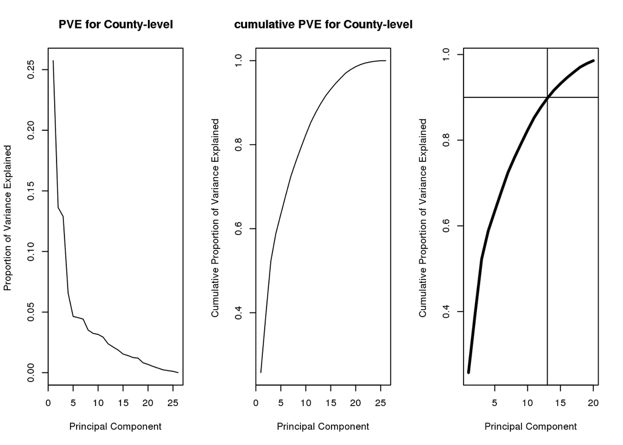

```
  According to graph, we need 13 PCs to explain 90%
```

#### For SubCounty-Level Data

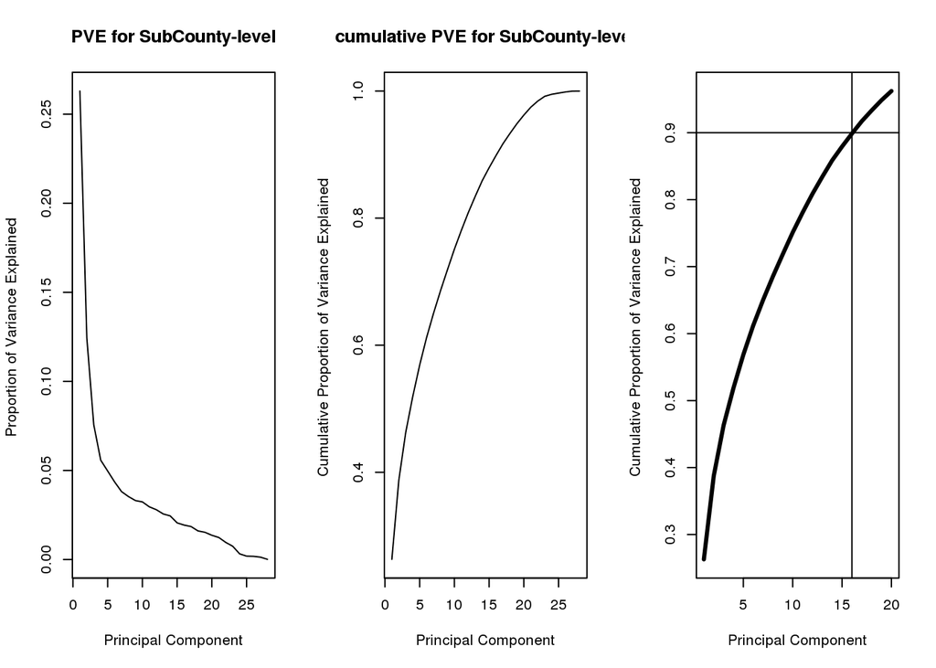

```
According to graph, we need 16 PCs to explain 90%
```

# Clustering

### 14 Hierarchical clustering with complete linkage

#### With census.ct, perform hierarchical clustering with complete linkage

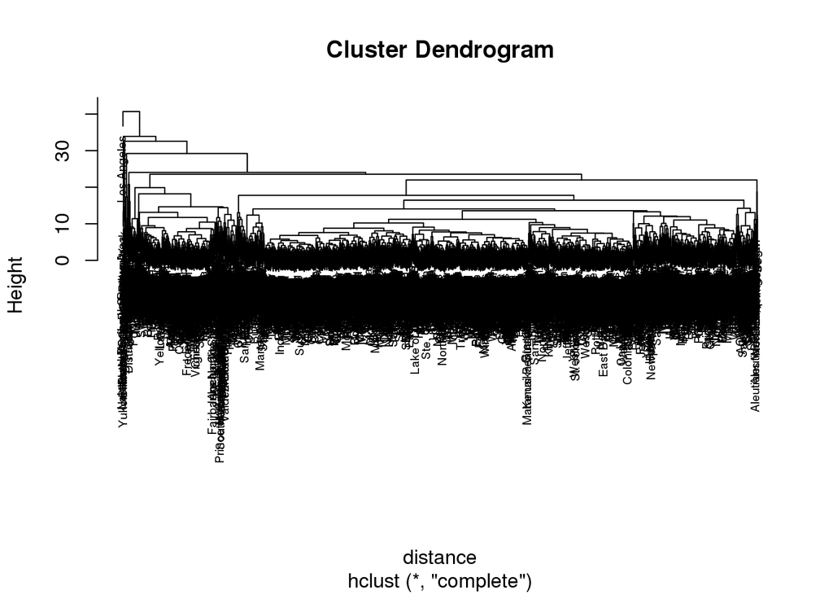

```
## clus
##    1    2    3    4    5    6    7    8    9   10
## 2632  501    6    7    5    1   11   13   38    4
```

```
## [1] 2
```

```
Most of counties are clustered in cluster1; while cluster2 countains much less counties. Other clusters also have quite less number of counties.
San Mateo County is clustered in Cluster2
```

#### Hierarchical clustering algorithm using the first 5 principal components

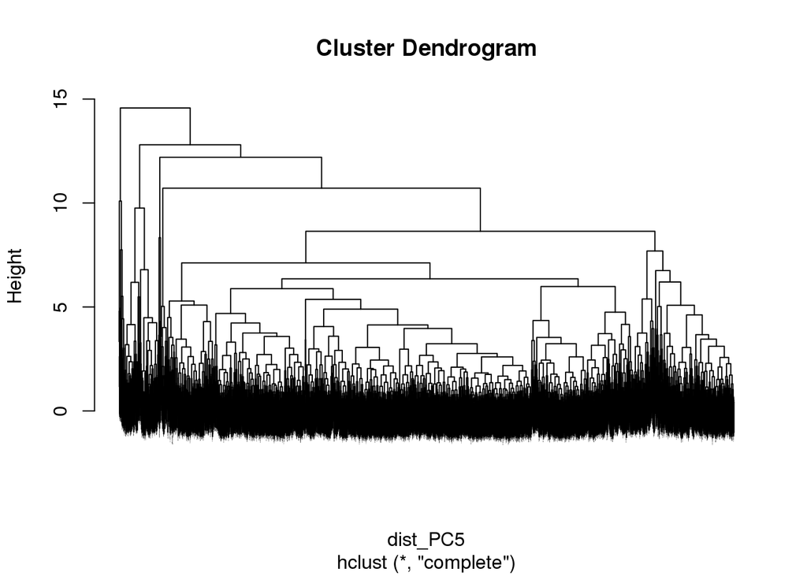

```
## clusPC5
##    1    2    3    4    5    6    7    8    9   10
## 2441  525   97    6    8   31    5   18    7   80
```

```
## [1] 1
```

[output not shown]

# Classificiation

### 15 Decision tree

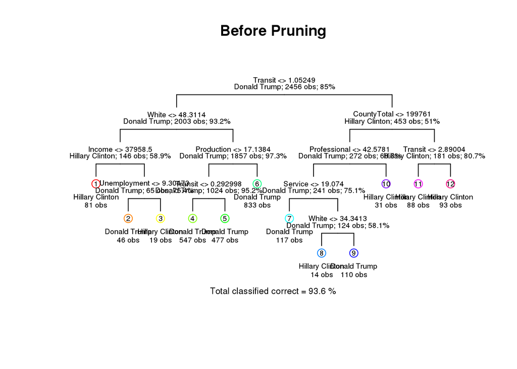

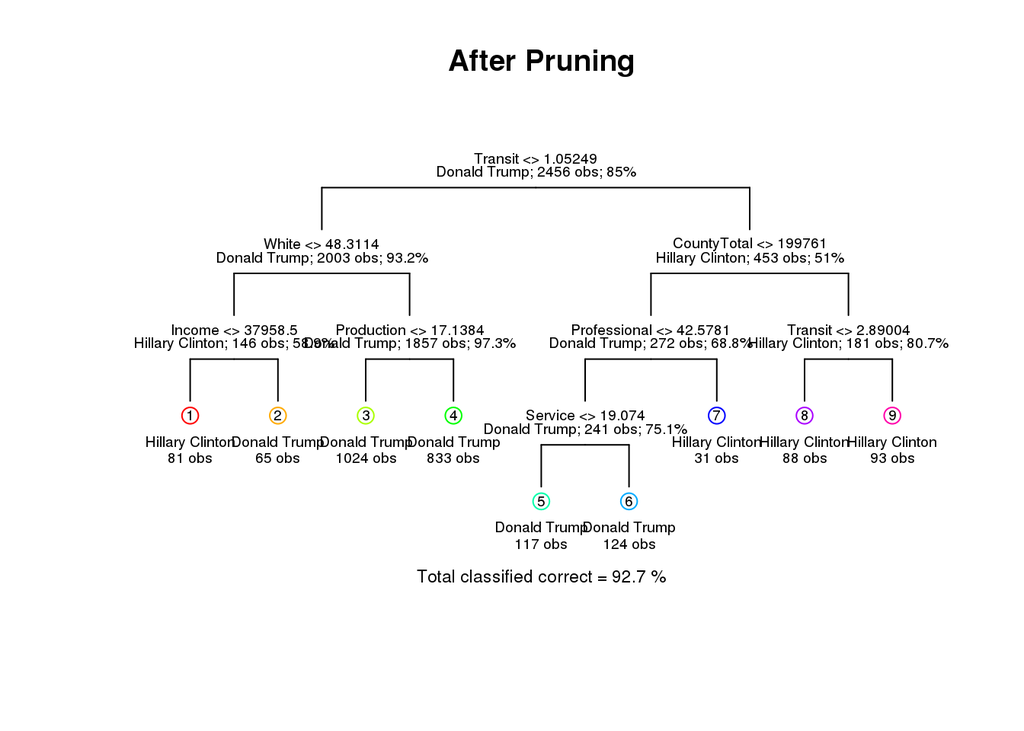

[output not shown]

### 16 Run a logistic regression

```
##
## Call:
## glm(formula = candidate ~ ., family = binomial, data = trn.cl.DT)
##
## Deviance Residuals:
##     Min       1Q   Median       3Q      Max
## -3.7362  -0.2705  -0.1133  -0.0407   3.5782
##
## Coefficients:
##                   Estimate Std. Error z value Pr(>|z|)
## (Intercept)     -1.158e+01  9.701e+00  -1.193 0.232686
## Men              8.346e-02  5.386e-02   1.550 0.121229
## White           -2.147e-01  6.550e-02  -3.278 0.001047 **
## Citizen          1.069e-01  3.049e-02   3.508 0.000452 ***
## Income          -7.558e-05  2.752e-05  -2.747 0.006016 **
## IncomeErr       -3.703e-05  6.269e-05  -0.591 0.554786
## IncomePerCap     2.669e-04  6.717e-05   3.974 7.07e-05 ***
## IncomePerCapErr -2.759e-04  1.308e-04  -2.109 0.034904 *
## Poverty          2.083e-02  4.110e-02   0.507 0.612267
## ChildPoverty    -7.147e-03  2.551e-02  -0.280 0.779357
## Professional     2.739e-01  3.972e-02   6.897 5.32e-12 ***
## Service          3.590e-01  4.953e-02   7.248 4.23e-13 ***
## Office           9.549e-02  4.801e-02   1.989 0.046688 *
## Production       1.811e-01  4.317e-02   4.196 2.72e-05 ***
## Drive           -2.542e-01  5.393e-02  -4.714 2.43e-06 ***
## Carpool         -2.441e-01  6.681e-02  -3.653 0.000259 ***
## Transit         -1.745e-02  1.022e-01  -0.171 0.864480
## OtherTransp     -9.864e-02  1.010e-01  -0.976 0.328820
## WorkAtHome      -2.093e-01  7.920e-02  -2.642 0.008238 **
## MeanCommute      6.120e-02  2.494e-02   2.454 0.014133 *
## Employed         1.650e-01  3.287e-02   5.021 5.14e-07 ***
## PrivateWork      8.717e-02  2.216e-02   3.934 8.36e-05 ***
## SelfEmployed     7.917e-03  4.674e-02   0.169 0.865516
## FamilyWork      -1.189e+00  4.080e-01  -2.914 0.003564 **
## Unemployment     1.813e-01  3.811e-02   4.758 1.96e-06 ***
## Minority        -8.369e-02  6.274e-02  -1.334 0.182229
## CountyTotal      3.666e-07  4.036e-07   0.908 0.363716
## ---
## Signif. codes:  0 '***' 0.001 '**' 0.01 '*' 0.05 '.' 0.1 ' ' 1
##
## (Dispersion parameter for binomial family taken to be 1)
##
##     Null deviance: 2074.96  on 2455  degrees of freedom
## Residual deviance:  853.13  on 2429  degrees of freedom
## AIC: 907.13
##
## Number of Fisher Scoring iterations: 7
```

[output not shown]

### 17 Control overfitting in logistic regression- LASSO

```
## 27 x 1 sparse Matrix of class "dgCMatrix"
##                             1
## (Intercept)     -1.985964e+01
## Men              4.845741e-02
## White           -1.226598e-01
## Citizen          1.176168e-01
## Income          -4.713544e-05
## IncomeErr       -4.323736e-05
## IncomePerCap     1.998650e-04
## IncomePerCapErr -2.017543e-04
## Poverty          1.649245e-02
## ChildPoverty     .
## Professional     2.478869e-01
## Service          3.294663e-01
## Office           6.814346e-02
## Production       1.482079e-01
## Drive           -2.092186e-01
## Carpool         -1.947376e-01
## Transit          2.688617e-02
## OtherTransp     -4.568407e-02
## WorkAtHome      -1.571981e-01
## MeanCommute      4.213346e-02
## Employed         1.564853e-01
## PrivateWork      7.934295e-02
## SelfEmployed     .
## FamilyWork      -1.040467e+00
## Unemployment     1.718720e-01
## Minority         .
## CountyTotal      4.634586e-07
```

```
According to the output above, we can see that most of the coeffecients are non-zero, except for ChildPoverty, SelfEmployed and Minority. Compared with the unpenalized logistic regression, this new LASSO model doesn't change too much, but it excludes three unsignificant variables.
```

```
##                     train.error test.error
## tree                 0.07288274 0.09120521
## logistic regression  0.06392508 0.07654723
## Lasso                0.06514658 0.07817590
```

```
The matrix records both the training error and test error for decision tree model, logistic regression model and LASSO regression model.
```

### 18 ROC

Based on your classification results, discuss the pros and cons of the various methods. Are different classifiers more appropriate for answering different kinds of problems or questions?

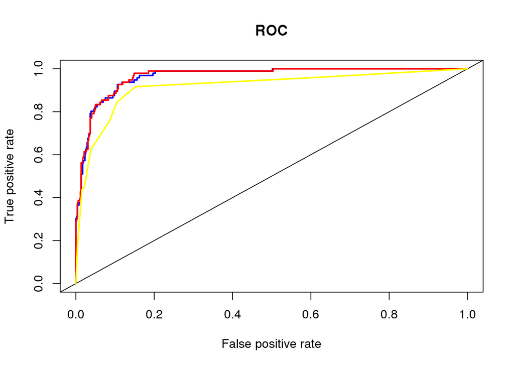

[output not shown]

# 19 Further Study

- Through this project, we utilitzes various data wrangling method and classification methods to predict the election result.

  For data wrangling procedure, we manipulate on our raw data to remove discrepencies because the raw dataset contains several mistakes such as misclassifying districts in counties, empty data in dataset, and so on. After wrangling, we make sure that our dataset readable and reasonable. As well as removing potential outliers and mistakes in future predictions and analysis.

  After that, we investigates the relationships between census data and election result. Considering demographics of census data related to people’s choices, we utilizes graphs to visulize the relationships. According to Step 10, we plot the relationship between election results with Income Per Capita, which is a measurement of weathness. Through the graph, we observe that weathier state would choose Hilary, while Poorer States generally choose Trump. Also we did PCA, with which we find out variables that impact voting reslt most. We observe that for county-level data, IncomePerCap is the largest absolute values in the loadings matrix. For sub-county level data, Transit is the largest absolute values in the loadings matrix for sub-county level data. Therefore, since IncomePerCap and % commuting on public transportation are both indicators of weathness, we could observe that weathness is important factor using PCA.

  These brief insights from graph and PCA provide a hint for us to do analysis because in afterwards prediction and analysis, we can clearly see that the variables related to wealthness could be the most important factors that impact people’s choice.

  Then, classification with decision tree, logistic regression, and lasso method are conducted. Comparing most important factors that these methods provided. Both original and pruned Decision Trees classifys that Transit is the most important feature. Logistic regression provides Citizen, IncomePerCap，Professional, Service Employed are significant. Since all of these features are related to income and therefore weathiness and poverty. These results is tally with our insight and assumptions that the weathiness is the most important features that impact the voting result.

  Then, we will conduct Boosting and Random Forest method to predict election result again.

#### Boosting Method

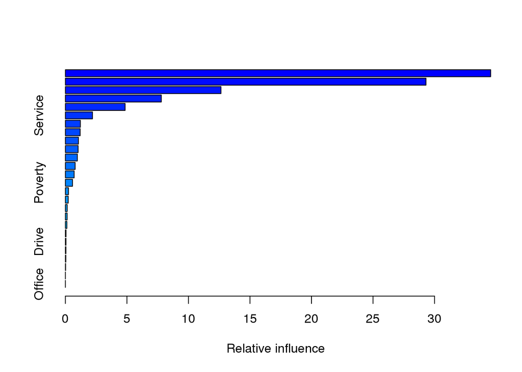

|  | var | rel.inf |
| --- | --- | --- |
| Transit | Transit | 34.562587 |
| White | White | 29.303426 |
| CountyTotal | CountyTotal | 12.644382 |
| Minority | Minority | 7.795267 |
| Professional | Professional | 4.854029 |
| Service | Service | 2.202243 |

```
So predictor Transit appears to be the most important.
```

#### Random Forest Method

|  | DT | HC | MeanDecreaseAccuracy | MeanDecreaseGini |
| --- | --- | --- | --- | --- |
| Men | 5.9016087 | 11.050358 | 11.75665 | 13.96733 |
| White | 24.2108802 | 33.708290 | 33.96801 | 72.80330 |
| Citizen | 13.2034305 | 5.941734 | 15.16244 | 16.25335 |
| Income | 9.6008543 | 13.843943 | 15.67152 | 18.41139 |
| IncomeErr | -0.5288525 | 11.810568 | 11.36564 | 13.02345 |
| IncomePerCap | 12.9020191 | 12.424378 | 17.84433 | 21.53227 |

[output not shown]

  Therefore, after we analyzed the relationships between census, region and election winner, we realize that demographics are important in our models. To make better prediction, we need to do more research on different people’s voting preferences, collect the data and make more useful suggestions for candidates. When we compare the Obama-Clinton’s election and Trump-Clintion’s election, we noticed that the most influential vairables are different, which change from Race and Education Level to Income and Transit. As we know, as the global environment changes, people’s concerns shift and many people changes their voting preferences as well. An interesting thing is that white people were more likely to vote for Clinton during Obama-Clinton’s election, however, most of they later chose to vote for Trump instead of Clinton. Based on that, we realize that our prediction is time-sensitive and the dataset needs to be updated every year. To analyze the data further and make our model more effective, we need to consider other practical problems such as the change of policy or international enviroment, and then try to set some error margins for our model, including considerations of other possible unexpected outcomes.